# Final S-SOMAS Analysis

Matt Dunham

6/30/2020

# 1 What Does Our Data Consist Of?

Our data consists of responses from college students enrolling in introductory Statistics classes. The data is on a 7-point likert scale. The students were randomly assigned to take either survey one or survey two, which both consisted of 49 to 50 items. The students were randomly split into two groups due to the length of the survey. The data files range from Fall 2017 to Fall 2019.

# 2 Factor Analysis

For Factor Analysis, we first need to determine the appropriate number of factor to use. In order to accomplish this, let us perform Parallel Analysis.

## 2.1 Parallel Analysis

For the first part of Parallel Analysis, we will obtain eigenvalues from our data. Eigenvalues can show us the appropriate number of factors we have in our data, and Exploratory Factor Analysis can show us which questions are loading onto which factors.

## 2.2 Scree Plots

Now that we have obtained our eigen values for group 1 and group 2, we can move forward with the rest of parallel analysis and scree plot generation.

Scree plot generation can help us visualize our eigen values and determine the number of factors we have in our data. When generating these scree plots, contrary to the eigenvalue generation, we will be using the raw data and not a numeric matrix.

In our generation of scree plots, there are a few arguments we can use. One of these arguments is the **cent** argument. In this argument, for group 1, we obtained a factor level of 4 or 5 depending on our cent level. Glorfeld 1995 & Hayton 2004 suggest a cent=.95, which is a more conservative approach. Parallel analysis tends to overestimate the number of factors, so we should consider using .95.

### 2.2.1 Group 1

For group 1, we will be using cent=0.5, although it is important to keep in mind that we were obtaining 4 factors with cent=0.95. The purpose for using cent = 0.5 and not 0.95 as advised by Glorfeld and Hayton is because we can simply drop this last factor if we are seeing very small loadings (since this is exploratory research).

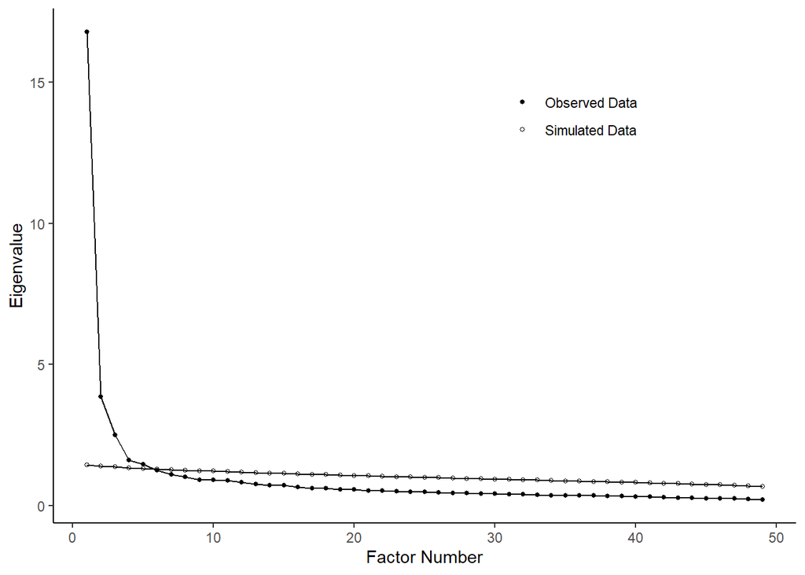

From this scree plot, we are seeing that we should extract 5 factors from our data. We will keep this in mind when moving to EFA.

### 2.2.2 Group 2

For group 2, we are obtaining the same number of factors regardless of our cent value. This can give us some level of confidence in this number, but this is still exploratory so we cannot say another for certain yet.

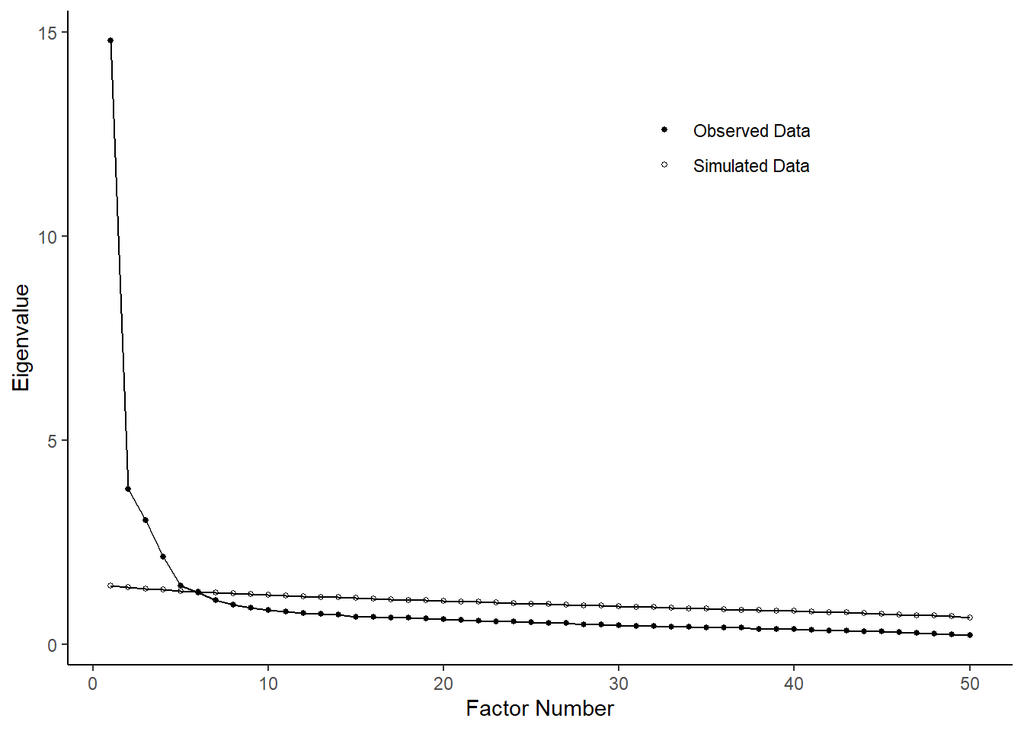

For group 2, we obtained 5 potential factors with the scree plot, so we will move forward with EFA keeping in mind this number.

We will now load our variables onto the amount of factors we obtained from Parallel Analysis.

## 2.3 Skew and Kurtosis

Before we go ahead with EFA, we will check skew and kurtosis to see if we are horribly violating our normality assumptions. For similar preseasons why we visualized our data so indepthly, the normality violations of our data can determine possible limitations with EFA arguments.

Violations follow these stipulations:

- Skew < 3
- Kurtosis < 10

```
## [1] 1.345373
```

```
## [1] 2.798181
```

```
## [1] 2.784069
```

```
## [1] 10.17224
```

# 3 Exploratory Factor Analysis

After Parallel Analysis and determining our maximum skew and kurtosis values, we can move ahead with Exploratory Factor Analysis. EFA will be conducted on each group separately, using what we obtained from parallel analysis, skew and kurtosis generation and our summary statistics.

Within the fa function, we are performing a promax rotation with a factoring method doing the principal factor solution. Along with this, we are using a polychoric correlation because we have data from a Likert scale, making our data ordinal and not continuous. This requires a polychoric correlation.

Using the fa function, we looked at two possible outcomes, one with a correction = 0 and one with a correction = 0.5. This correction determines how we should treat empty cells, but in the end did not change our loadings much at all. We went ahead with a correction = 0.

These arguments and function selection are consistent across both the groups.

## 3.1 Sorting Method

We also will be printing out two versions of the loadings for each group: one where the variables are ordered (designed to show how well constructs are holding up), and another where the loadings are ordered by magnitude and factor (where we can see what the new constructs are looking like). Visualizing these loadings in these two different ways can help us when it comes to interpreting our EFA results and making decisions about question wording and new hypothesized constructs.

### 3.1.1 Group 1

**5 Factors (sorted by variable name)**

```
##
## Loadings:
##             PA2    PA1    PA4    PA3    PA5
## Belief_1            0.708
## Belief_2
## Belief_3           -0.574
## Belief_4
## Belief_5
## Belief_6            0.673
## Belief_7            0.596
## Belief_8            0.604
## Belief_9            0.734
## Belief_10    0.725                       0.479
## Intrinsic_1 -0.608
## Intrinsic_2                0.433
## Intrinsic_3         0.652
## Intrinsic_4         0.418
## Intrinsic_5         0.631
## Intrinsic_6 -0.570
## Intrinsic_7         0.713
## Extrinsic_1                0.522
## Extrinsic_2                0.543
## Extrinsic_3                0.503
## Extrinsic_4                0.679
## Extrinsic_5                0.752
## Extrinsic_6                       0.451
## Extrinsic_7                       0.476
## Extrinsic_8                       0.554
## Utility_1                  0.661
## Utility_2                  0.492
## Utility_3                 -0.449
## Utility_4           0.731
## Utility_5
## Utility_6           0.768
## Utility_7           0.724
## Utility_8                 -0.577
## Attain_1     0.519
## Attain_2     0.784
## Attain_3     0.434
## Attain_4
## Attain_5                                 0.459
## Attain_6                                 0.630
## Attain_7                                 0.483
## Interest_1   0.872
## Interest_2  -0.628
## Interest_3   0.866
## Interest_4  -0.575
## Interest_5  -0.847
## Interest_6  -0.537
## Interest_7   0.728
## Interest_8   0.828
## Interest_9  -0.575
##
##                  PA2   PA1   PA4   PA3   PA5
## SS loadings    8.229 6.627 3.725 2.018 1.749
## Proportion Var 0.168 0.135 0.076 0.041 0.036
## Cumulative Var 0.168 0.303 0.379 0.420 0.456
```

**5 Factors (sorted by loading magnitude)**

```
##
## Loadings:
##             PA2    PA1    PA4    PA3    PA5
## Interest_1   0.872
## Interest_3   0.866
## Interest_5  -0.847
## Interest_8   0.828
## Attain_2     0.784
## Interest_7   0.728
## Belief_10    0.725                       0.479
## Interest_2  -0.628
## Intrinsic_1 -0.608
## Interest_9  -0.575
## Interest_4  -0.575
## Intrinsic_6 -0.570
## Interest_6  -0.537
## Attain_1     0.519
## Attain_3     0.434
## Attain_4
## Belief_2
## Utility_6           0.768
## Belief_9            0.734
## Utility_4           0.731
## Utility_7           0.724
## Intrinsic_7         0.713
## Belief_1            0.708
## Belief_6            0.673
## Intrinsic_3         0.652
## Intrinsic_5         0.631
## Belief_8            0.604
## Belief_7            0.596
## Belief_3           -0.574
## Intrinsic_4         0.418
## Belief_5
## Extrinsic_5                0.752
## Extrinsic_4                0.679
## Utility_1                  0.661
## Utility_8                 -0.577
## Extrinsic_2                0.543
## Extrinsic_1                0.522
## Extrinsic_3                0.503
## Utility_2                  0.492
## Utility_3                 -0.449
## Intrinsic_2                0.433
## Utility_5
## Extrinsic_8                       0.554
## Extrinsic_7                       0.476
## Extrinsic_6                       0.451
## Belief_4
## Attain_6                                 0.630
## Attain_7                                 0.483
## Attain_5                                 0.459
##
##                  PA2   PA1   PA4   PA3   PA5
## SS loadings    8.229 6.627 3.725 2.018 1.749
## Proportion Var 0.168 0.135 0.076 0.041 0.036
## Cumulative Var 0.168 0.303 0.379 0.420 0.456
```

### 3.1.2 Group 2

For group 2, we clearly obtained 5 factors from our scree plots, so we will do a 5 factor EFA using the same arguments and function as group 1.

**5 Factors (sorted by variable name)**

```
##
## Loadings:
##               PA2    PA1    PA3    PA4    PA5
## AcadSC_1                                   0.620
## AcadSC_2              0.551
## AcadSC_3                           -0.445
## AcadSC_4
## AcadSC_5                            0.656
## AcadSC_6
## AcadSC_7                            0.822
## AcadSC_8
## AcadSC_9                            0.838
## Attain_1                    -0.456
## Attain_2                    -0.691
## Attain_3                    -0.623
## Attain_4                     0.594
## Attain_5                                   0.714
## Attain_6                     0.456         0.504
## Attain_7                                   0.426
## StatSC_1              0.563
## StatSC_2      -0.580
## StatSC_3              0.461
## StatSC_4       0.790
## StatSC_5       0.433
## StatSC_6              0.456
## StatSC_7       0.658
## StatSC_8       0.737
## StatSC_9                            0.619
## Difficult_1    0.808
## Difficult_2   -0.452
## Difficult_3   -0.794
## Difficult_4
## Difficult_5
## Difficult_6    0.752
## Difficult_7    0.880
## Expectancy_1   0.597
## Expectancy_2          0.684
## Expectancy_3          0.617
## Expectancy_4          0.698
## Expectancy_5          0.652
## Expectancy_6   0.639
## Expectancy_7          0.529  0.465
## Expectancy_8          0.605
## Expectancy_9          0.460
## Expectancy_10         0.613
## Expectancy_11        -0.406
## Cost_1                       0.779
## Cost_2                       0.682
## Cost_3                      -0.627
## Cost_4                      -0.753
## Cost_5         0.544
## Cost_6                       0.730
## Cost_7         0.462
##
##                  PA2   PA1   PA3   PA4   PA5
## SS loadings    7.105 5.582 4.709 3.624 1.819
## Proportion Var 0.142 0.112 0.094 0.072 0.036
## Cumulative Var 0.142 0.254 0.348 0.420 0.457
```

**5 Factors (sorted by loading magnitude)**

```
##
## Loadings:
##               PA2    PA1    PA3    PA4    PA5
## Difficult_7    0.880
## Difficult_1    0.808
## Difficult_3   -0.794
## StatSC_4       0.790
## Difficult_6    0.752
## StatSC_8       0.737
## StatSC_7       0.658
## Expectancy_6   0.639
## Expectancy_1   0.597
## StatSC_2      -0.580
## Cost_5         0.544
## Cost_7         0.462
## Difficult_2   -0.452
## StatSC_5       0.433
## AcadSC_8
## Difficult_4
## Expectancy_4          0.698
## Expectancy_2          0.684
## Expectancy_5          0.652
## Expectancy_3          0.617
## Expectancy_10         0.613
## Expectancy_8          0.605
## StatSC_1              0.563
## AcadSC_2              0.551
## Expectancy_7          0.529  0.465
## StatSC_3              0.461
## Expectancy_9          0.460
## StatSC_6              0.456
## Expectancy_11        -0.406
## AcadSC_4
## AcadSC_6
## Difficult_5
## Cost_1                       0.779
## Cost_4                      -0.753
## Cost_6                       0.730
## Attain_2                    -0.691
## Cost_2                       0.682
## Cost_3                      -0.627
## Attain_3                    -0.623
## Attain_4                     0.594
## Attain_1                    -0.456
## AcadSC_9                            0.838
## AcadSC_7                            0.822
## AcadSC_5                            0.656
## StatSC_9                            0.619
## AcadSC_3                           -0.445
## Attain_5                                   0.714
## AcadSC_1                                   0.620
## Attain_6                     0.456         0.504
## Attain_7                                   0.426
##
##                  PA2   PA1   PA3   PA4   PA5
## SS loadings    7.105 5.582 4.709 3.624 1.819
## Proportion Var 0.142 0.112 0.094 0.072 0.036
## Cumulative Var 0.142 0.254 0.348 0.420 0.457
```

## 3.2 Histograms of New Empirical Factors

The Effort Scale in the SATS has an issue with being too skewed where students are overall believing they put a lot of effort into learning statistics, regardless of the outcome or change in knowledge. Visualizing these new empirical factors may show some issues that can be addressed in future edits.

### 3.2.1 Group 1

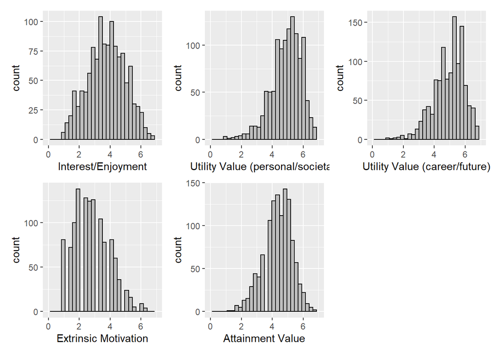

### 3.2.2 Group 2

Histograms of each empirical factor determined from Factor Analysis for Group 2.

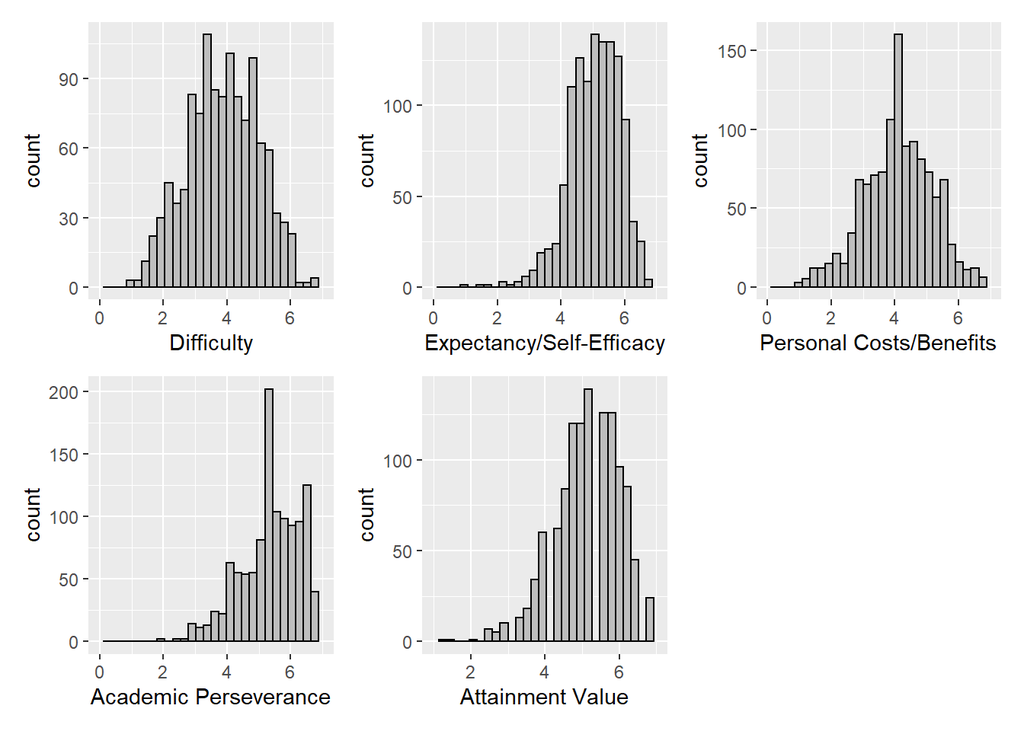

## 3.3 Tables of Means and Standard Deviations for each new Empirical Factor

We will generate a table for each group of the mean and standard deviation for both groups.

### 3.3.1 Group 1

```
## * . -> ....1
## * . -> ....2
## * . -> ....3
```

Means and Std. Devs. for Empirical Factors in Group 1

| Factor Name | Mean | Standard Deviation |
| --- | --- | --- |
| Interest/Enjoyment | 3.781 | 1.204 |
| Utility Value (personal/societal | 4.930 | 0.986 |
| Utility Value (career/future) | 4.987 | 0.997 |
| Extrinsic Motivation | 2.814 | 1.159 |
| Attainment Value | 4.347 | 0.883 |

### 3.3.2 Group 2

```
## * . -> ....1
## * . -> ....2
## * . -> ....3
```

Means and Std. Devs. for Empirical Factors in Group 2

| Factor Name | Mean | Standard Deviation |
| --- | --- | --- |
| Difficulty | 3.878 | 1.111 |
| Expectancy/Self-Efficacy | 5.072 | 0.794 |
| Personal Costs/Benefits | 4.120 | 1.070 |
| Academic Perseverace | 5.396 | 0.943 |
| Attainment Value | 5.171 | 0.889 |

# 4 Summaries and Future Implications

We now will discuss some of the implications and findings from the results above, as well as take a visual representation of how the theoretical constructs now map onto the empirical factors.

## 4.1 Sankey Diagrams

We will use a Sankey diagram to path each theoretical construct to their new empirical factors.

### 4.1.1 Group 1

Sankey Diagram for Group 1.

[interactive chart not shown]

### 4.1.2 Group 2

Sankey Diagram for Group 2.

[interactive chart not shown]

## 4.2 Specifics About Our Loadings

### 4.2.1 Group 1

**How Many Items Have No Loadings > |0.4|:**

We have **5** items with insignificant loadings:

- Belief_2
- Belief_4
- Belief_5
- Utility_5
- Attain_4

**How Many Items Cross-Load:**

We have **1** items with cross-loadings:

- Belief_10

**How Many Items Have A “Clean” Factor:**

We have **43** items with clean loadings (all items for group 1 but those listed above).

### 4.2.2 Group 2

**How Many Items Have No Loadings > |0.4|:**

We have **5** items with insignificant loadings:

- AcadSC_4
- AcadSC_6
- AcadSC_8
- Difficult_4
- Difficult_5

**How Many Items Cross-Load:**

We have **2** items with cross-loadings:

- Attain_6
- Expectancy_7

## 4.3 What Can We Theorize About Our New Factors?

We obtained new constructs from EFA with many items from multiple constructs making up our new constructs. This means we most likely will have new definitions for our constructs. We will look to analyze the questions in each of the new constructs and define what this construct may be attempting to capture.

*IMPORTANT NOTE: (-) represents the item is negatively worded.*

### 4.3.1 Group 1

I will list the questions for each new construct and give some idea of how/why these questions are loading together.

Variables in our Factor:

- Utility_6: Statistics will help me understand news reports.
- Utility_7: I value statistics because it makes me an informed citizen.
- Intrinsic_7: I want to know statistics to make informed choices for myself (e.g. health, politics, etc.).
- Intrinsic_3: I want to learn statistics to be a better consumer of information.
- Utility_4: Statistics is helpful for understanding the world around me.
- Belief_1: Statistics helps makes sense of the world.
- Belief_9: Statistics can be used to make people’s lives better.
- Intrinsic_5: I want to learn statistics so that I can be a competent citizen.
- Belief_6: Statistics help us solve complex problems in society.
- Belief_8: Statistics is a tool for discovering patterns in data.
- Belief_7: Statistics is broadly applicable in many fields.
- Intrinsic_4: I want to understand how statistics are used in everyday life.
- (-) Belief_3: There is little use for statistics outside the classroom. *newly loaded with spring data*

**Potential New Definition:**

This factor seems to be pertaining to the usefulness of statistics in personal and societal terms. This is captured mainly through positively worded items.

Variables in our Factor:

- (-) Interest_1: I find statistics frustrating.
- (-) Interest_3: I find statistics boring.
- (-) Interest_8: I dread statistics.
- (-) Attain_2: If I could choose, I would never do statistics in the future.
- (-) Interest_7: I find little enjoyment in doing statistics.
- Interest_5: Doing statistics is fun for me.
- (-) Belief_10: Statistics is intimidating.
- (-) Attain_1: I would only learn statistics if it helped me achieve my goals.
- Interest_2: I am interested in learning more about statistics.
- Interest_4: Using statistics to solve real-world problems is personally enjoyable
- Interest_9: I think conversations about statistics are stimulating.
- Intrinsic_1: I want to learn statistics.
- Interest_6: I am curious about statistics.
- Intrinsic_6: I want to learn statistics for my personal fulfillment.

*Negatively worded items load positively due to the amount of negative items and their loading magnitudes.*

Potential New Definition:

This factor seems to be pertaining to the interest of statistics. Interest seems to be captured mainly with negatively worded items.

**New Factor 3 (Utility Value (future/career)**

**Potential New Definition:**

This factor seems to be pertaining to the usefulness of statistics in regards to their career and future.

**New Factor 4 (Extrinsic Motivation)**

Variables in our Factor:

- Extrinsic_8: I need to know statistics because my family wants me to.
- Extrinsic_7: I need to know statistics because someone important to me wants me to.
- Extrinsic_6: I need to know statistics so that I appear intelligent to my peers.

**Potential New Definition:**

This factor seems to be pertaining to the Extrinsic motivators for needing to know statistics. The motivators are due to others wanting them to learn statistics (to appear smart, family) not school.

**New Factor 5 (Attainment Value)**

Variables in our Factor:

- Attain_6: Doing well in statistics is important to my sense of self.
- Attain_5: If I did poorly in a statistics course, I would be disappointed in myself.
- Attain_7: If I am unable to interpret statistical results, I feel insecure.

**Potential New Definition:**

This factor seems to be pertaining to the attainment value or how well an individual wants to do well in statistics. The questions are generally to avoid feeling bad/disappointed.

### 4.3.2 Group 2

I will list the questions for each new construct and give some idea of how/why these questions are loading together.

**New Factor 1 (Difficulty)**

Variables in our Factor:

- (-) Difficult_7: Learning statistics for the first time is hard.
- (-) Difficult_1: You must work hard to understand statistics.
- (-) StatSC_4: I have trouble understanding statistics.
- (-) Difficult_6: It is challenging to solve a problem that requires using statistics.
- Difficult_3: Statistics is easy.
- (-) StatSC_8: I often need guidance to understand statistics.
- (-) StatSC_7: When I see a statistics question, I am unsure of how to begin.
- (-) Expectancy_6: I find it challenging to decide which statistical method to use in a given context.
- (-) Expectancy_1: I struggle to interpret statistical results.
- (-) Cost_5: Taking statistics will limit my future prospects (for example, lower my GPA).
- StatSC_2: I am good at statistics.
- (-) Cost_7: I avoid working on statistics because it makes me feel bad.
- (-) StatSC_5: I lack the skills to do well in statistics.
- Difficult_2: Interpreting statistical results is straightforward. *newly added with spring*

*Negatively worded items load positively due to the amount of negative items and their loading magnitudes.*

**Potential New Definition:**

This factor seems to be pertaining to the difficulty of statistics. This is captured mainly through negatively worded items.

**New Factor 2 (Expectancy/Self-Efficacy)*

Variables in our Factor:

**Potential New Definition:**

This factor seems to be pertaining to expectancy/self-efficacy. The items are all positively worded.

**New Factor 3 (Personal Costs/Benefits)**

Variables for our Factor:

- (-) Cost_4: I have more important things to do than spending time learning statistics.
- Cost_1: Learning statistics is a good use of my time.
- Cost_6: Learning statistics is worth spending money on.
- (-) Attain_2: If I could choose, I would never do statistics in the future.
- (-) Cost_3: I prioritize other tasks over statistics.
- Cost_2: Acquiring statistical skills is worth the effort.
- (-) Attain_3: I do not care if I understand statistics.
- Attain_4: Understanding statistics empowers me.
- (-) Attain_1: I would only learn statistics if it helped me achieve my goals.

*Negatively worded items load positively due to the amount of negative items and their loading magnitudes.*

**Potential New Definition:**

This factor seems to be pertaining to the cost/attainment value of statistics (personal costs/benefits). Items are predominantly negative, but have a mix of the two.

**New Factor 4 (Academic Perseverance)**

Variables for our Factor

- (-) AcadSC_9: When I fail at something, I immediately give up.
- (-) AcadSC_7: When learning becomes difficult, I usually give up.
- (-) AcadSC_5: I avoid working on things that are intimidating to me.
- (-) StatSC_9: When statistics becomes challenging, I stop trying.
- AcadSC_3: If I can’t solve a problem right away, I will try again.

*Negatively worded items load positively due to the amount of negative items and their loading magnitudes.*

**Potential New Definition:**

This factor seems to be pertaining to persistence in a general term. Most questions are regarding general persistence, with one regarding statistical persistence.

**New Factor 5 (Attainment Value)**

Variables for our Factor:

- Attain_5: If I did poorly in a statistics course, I would be disappointed in myself.
- AcadSC_1: Doing well in school is important to me.
- Attain_6: Doing well in statistics is important to my sense of self.
- Attain_7: If I am unable to interpret statistical results, I feel insecure.

**Potential New Definition:**

This factor seems to be pertaining to attainment value in regards to an individual wanting to do well for themselves. These items differ from the other attainment items as these are positively worded.

## 4.4 Negatively and Positively Worded Items

Negatively and positively worded items have the potential to add another layer of complexity in measurement development. These negative and positive items can potentially cluster together due to the framing of the question rather than the underlying factor trying to be measured. It is important to look at potential patterns with these items to ensure our measurement tool measures what we intend it to.

Below contains summaries regarding these items.

### 4.4.1 Group 1

**Key Point For Each New Factor:**

### 4.4.2 Group 2

**Key Point For Each New Factor:**

- The new **Difficulty factor** contained predominantly negatively worded items with few positively worded items. The negative item loadings are so extreme they load positively.
- The new **Expectancy/Self-Efficacy factor** contained all positively worded items.
- The new **Personal Costs/Benefits factor** contains a mix of positively and negatively worded items, but more negatively worded items. The negative items load so significantly they load positively.
- The new **Academic Persistence factor** contained predominantly negatively worded items, so much so they loaded positively.
- The new **Attainment (wanting to do well) factor** contained all positively worded items.

### 4.4.3 Groups 1 and 2

The attainment construct in both groups split, with one factor containing the negative items and another containing the positive items. The negative items split clearly into another related factor and the positive items stayed in their own separate factor (although, it is the most insignificant factor).

## 4.5 What Happened With Our Theorized Constructs?

Let us discuss our theorized constructs for each group and how this new analysis may have changed how our constructs are looking now.

### 4.5.1 Group 1

**Key Points Regarding Our Theorized Constructs For Group 1:**

### 4.5.2 Group 2

**How Each Construct Turned Out:**

**Key Points Regarding Our Theorized Constructs For Group 2:**

- Two theorized constructs (Expectancy and Cost) held up fairly well, but not all items loaded on the same factor for any item.
- Many items split onto two different factors or had a few items too insignificant to load.
- The fourth and fifth factor are not containing many significant loadings, showing that we may only need four factors.

### 4.5.3 Groups 1 & 2

**Key Points Regarding Similarities in Our Theorized Constructs For Group 1 and Group 2:**